# White Wine Quality Exploration by Najlaa Shariefi

```
##    Min. 1st Qu.  Median    Mean 3rd Qu.    Max.
##   0.600   1.700   5.200   6.391   9.900  65.800
```

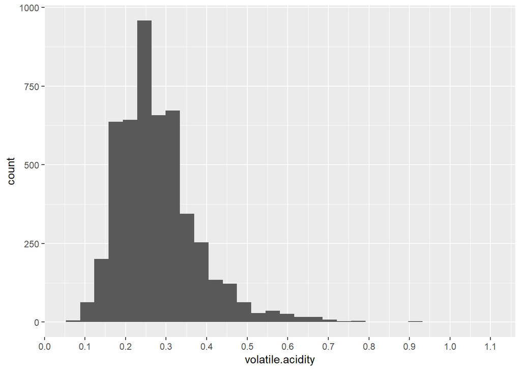

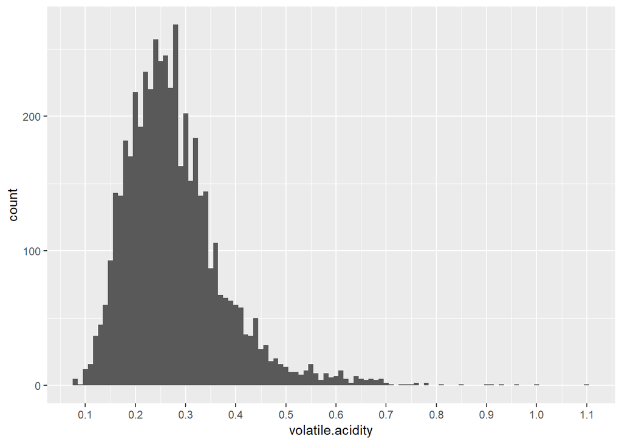

```
##    Min. 1st Qu.  Median    Mean 3rd Qu.    Max.
##  0.0800  0.2100  0.2600  0.2782  0.3200  1.1000
```

Zooming in into the distribution of the volatile acidity level of the wine samples , the distribution appears to be right skewed with multiple outliers at 0.7 and above. The bulk of the data seems to be from 0.15 to 0.35. Since the distribution is right skewed, the best measure for the center is the median which is equals to 0.26 . It is worth mentioning that although the volatile acidity levels range from 0.08 - 1.1, 50% of the data lies between 0.21(1st Qu) and 0.32 (3rd Qu).

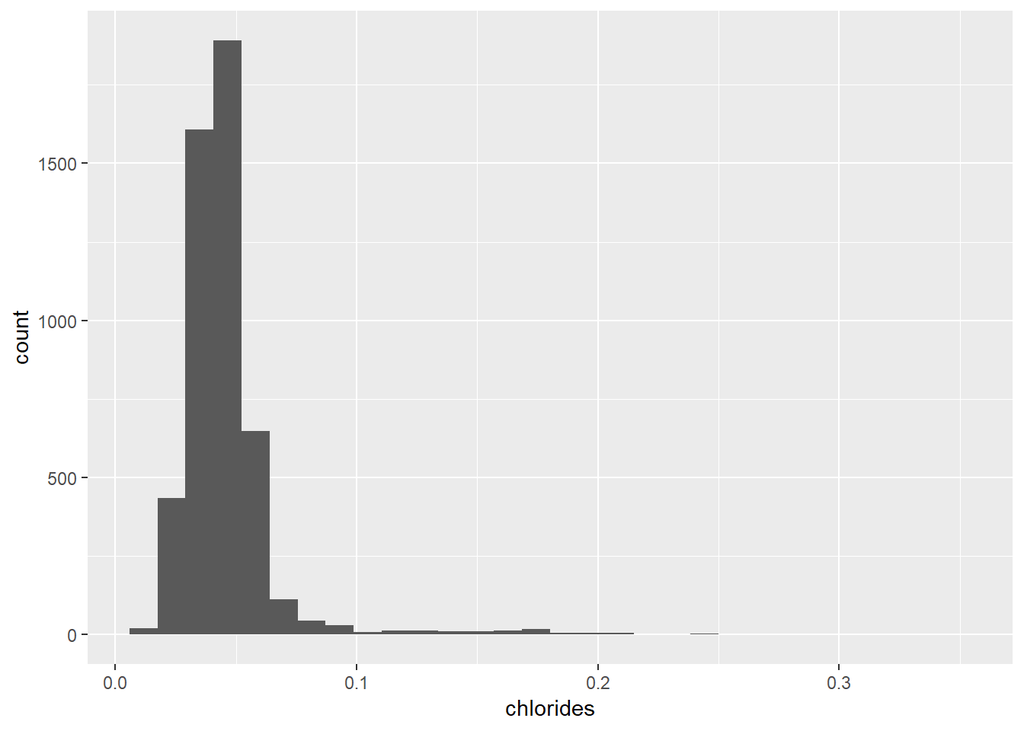

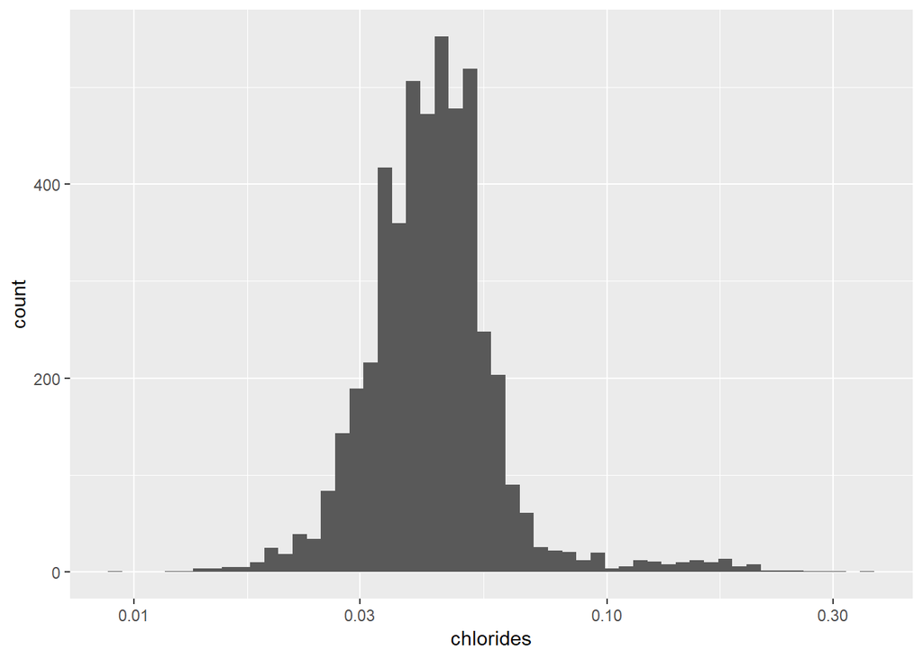

```
##    Min. 1st Qu.  Median    Mean 3rd Qu.    Max.
## 0.00900 0.03600 0.04300 0.04577 0.05000 0.34600
```

The distribution of the chlorides appears to be a long tailed right skewed one. In my opinion , I think that the median is a better measure for the center than the mean. This is True especially for the Long-tailed data where the higher values in chlorides is going to pull the mean to the right. i.e. a few wine samples with high chloride level will drag the mean upwards which is not necessarily the correct representative of most samples. As mentioned above,the median (0.043), in our case, is a better measure for the center because it is a more robust statistic. The median resistant to change, since it marks the half way point for all the data points. However, Transforming the long tail data using the log base 10 turned our distribution into something that is more closely to a normal distribution. The data has one outlier at the chlorides value of 0.346. When it comes to the peaks, the distribution has two peaks, one is at 0.036 and the other one is at 0.044.

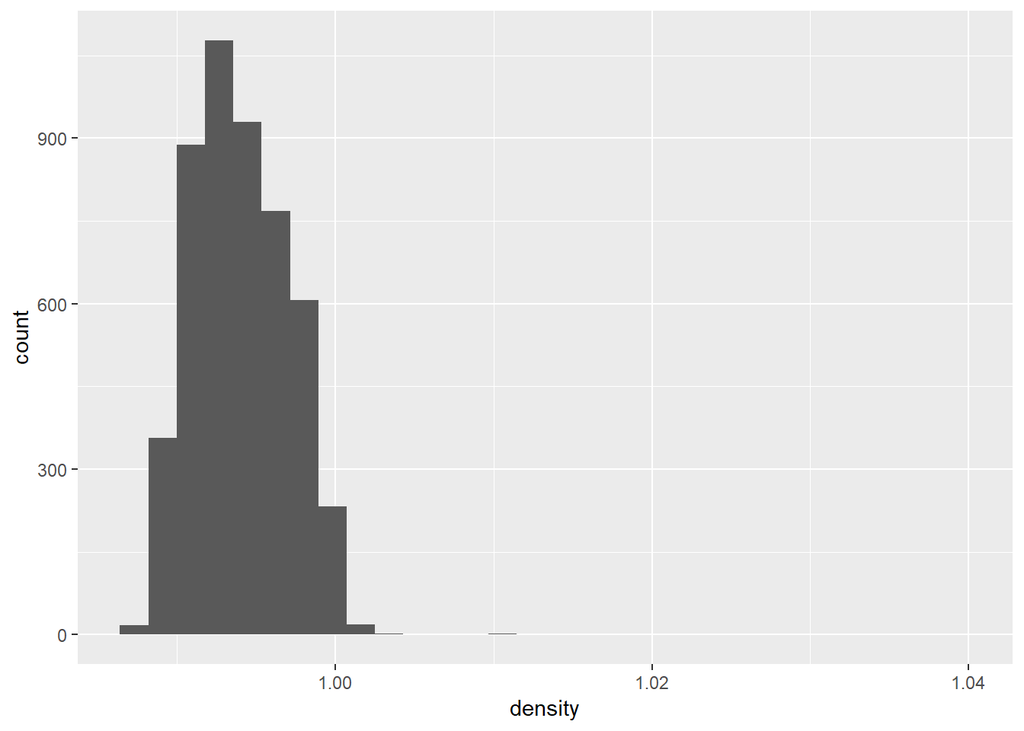

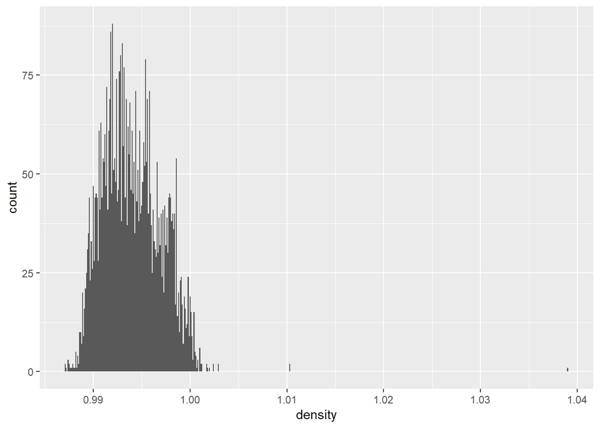

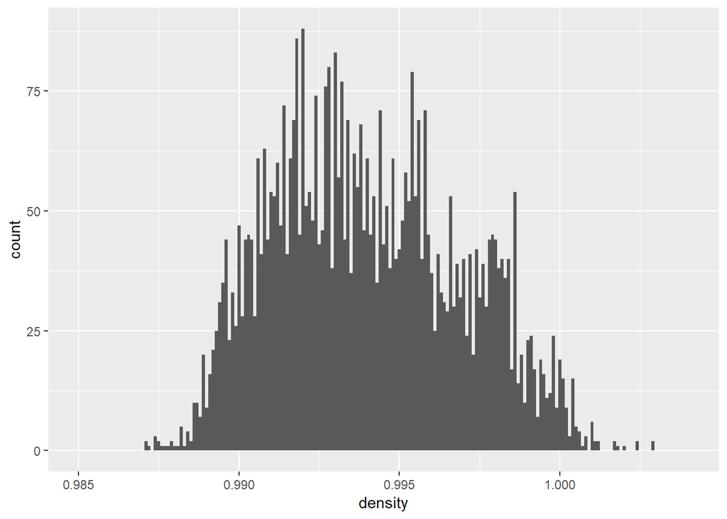

```
##    Min. 1st Qu.  Median    Mean 3rd Qu.    Max.
##  0.9871  0.9917  0.9937  0.9940  0.9961  1.0390
```

Plotting the distribution of density showed a plot with the bulk of its data appeared at the left side of the graph. Most of the wine samples has a density that falls within the range of 0.989 - 1.000. Almost half of the plot’s x-axis was not clearly presenting any data. Furthermore, adjusting the bin width of the histogram led to a plot with clear outliers located around 1.01 and 1.04. After we Zoomed in by setting the plot’s limits,a message appears indicating that only a total of 5 rows has been removed, proving that the limits have been chosen correctly. However, we ended up with a final Multimodal plot showing with a distribution that can be considered almost normally distributed. In my opinion, I think that the mean of 0.9940 would be a better measure of the center. Talking about the outliers ,I think that the distribution has one outlier at 1.03898.

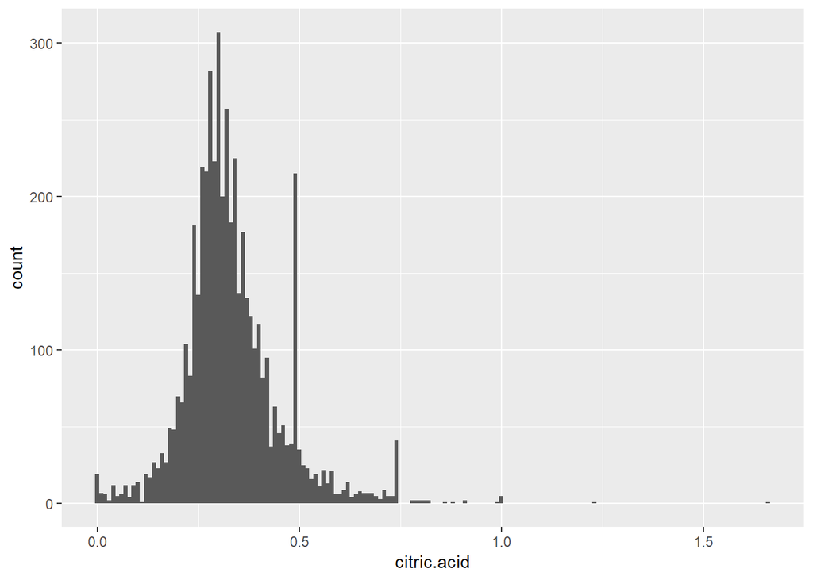